# An Analysis of Child Health in Kenyan Counties

Author: Steve Githinji

2023-07-20

## Business Problem

A non-profit organization dedicated to improving child health in Kenya aims to understand the current status of child health indicators across various counties. They seek to identify trends, regional disparities, and potential factors affecting child health. Additionally, the organization wishes to evaluate the impact of deworming programs on reducing diarrhea cases among children.

To address these objectives, the organization needs an in-depth analysis of data spanning from January 2021 to June 2023, focusing on indicators like acute malnutrition, stunting, diarrhea cases, and underweight children. By gaining insights into these aspects, the organization hopes to develop targeted interventions to promote healthier child development, reduce health disparities among counties, and enhance the effectiveness of deworming initiatives in combating diarrhea cases.

## Objectives

- To identify trends in child health indicators by examining how acute malnutrition, stunting, diarrhea cases, and underweight children cases have evolved over the period from January 2021 to June 2023
- To identify regional disparities in child health between different counties in Kenya
- To investigate if there are significant differences in health indicators between different age groups (0-6 months, 6-23 months, and 24-59 months)
- To investigate impact of deworming programs on prevalence of diarrhea cases

## Data Understanding

In this section, we will load and preview the data from the CSV file named “cema_internship_task_2023.csv” located inside then preview the data.

```r
# Load data from CSV
data <- read.csv("data/cema_internship_task_2023.csv")

# Preview the data
head(data)
```

```
##   period                 county Total.Dewormed Acute.Malnutrition
## 1 Jan-23         Baringo County           3659                  8
## 2 Jan-23           Bomet County           1580                 NA
## 3 Jan-23         Bungoma County           6590                 24
## 4 Jan-23           Busia County           7564                 NA
## 5 Jan-23 Elgeyo Marakwet County           1407                 NA
## 6 Jan-23            Embu County           3241                 72
##   stunted.6.23.months stunted.0..6.months stunted.24.59.months diarrhoea.cases
## 1                 471                  34                  380            2620
## 2                   1                   3                   NA            1984
## 3                  98                 154                   23            4576
## 4                 396                 143                  111            2239
## 5                  92                  71                    5            2739
## 6                 326                  86                   24            1376
##   Underweight.0..6.months Underweight.6.23.months Underweight.24.59.Months
## 1                      85                     739                      731
## 2                      41                      86                       16
## 3                     231                     315                      120
## 4                     251                     608                      125
## 5                      57                     104                       21
## 6                     141                     544                      160
```

The dataset contains monthly data for children <5 years, disaggregated at a county level for the period January 2021 to June 2023.

The county column contains the suffix ‘County’ in each entry. Below, we remove this suffix for tidier visualiztions later.

```r
# Load stringr library
library(stringr)
# Remove 'County' suffix
data$county <- gsub("County$", "", data$county)
# Remove leading and trailing whitespaces in the 'county' column
data$county <- str_trim(data$county)
```

Here we use glimpse() method to get an informative summary of the data frame’s structure, showing the first few rows of the data and the data types of each variable.

```r
# Load dplyr package with message suppressed
suppressMessages(library(dplyr))

# Get concise summary
glimpse(data)
```

```
## Rows: 1,410
## Columns: 11
## $ period                   <chr> "Jan-23", "Jan-23", "Jan-23", "Jan-23", "Jan-…
## $ county                   <chr> "Baringo", "Bomet", "Bungoma", "Busia", "Elge…
## $ Total.Dewormed           <int> 3659, 1580, 6590, 7564, 1407, 3241, 6751, 469…
## $ Acute.Malnutrition       <int> 8, NA, 24, NA, NA, 72, 250, 9, 26, 104, 36, N…
## $ stunted.6.23.months      <int> 471, 1, 98, 396, 92, 326, 40, 209, 51, 319, 2…
## $ stunted.0..6.months      <int> 34, 3, 154, 143, 71, 86, 13, 87, 6, 102, 279,…
## $ stunted.24.59.months     <int> 380, NA, 23, 111, 5, 24, 99, 58, 50, 155, 292…
## $ diarrhoea.cases          <int> 2620, 1984, 4576, 2239, 2739, 1376, 2314, 278…
## $ Underweight.0..6.months  <int> 85, 41, 231, 251, 57, 141, 223, 140, 13, 139,…
## $ Underweight.6.23.months  <dbl> 739, 86, 315, 608, 104, 544, 1856, 298, 180, …
## $ Underweight.24.59.Months <dbl> 731, 16, 120, 125, 21, 160, 1833, 84, 271, 57…
```

The dataset contains 1,410 rows and 11 columns. Data types pressent include integers, characters and doubles. Next we generate summary statistics for each numerical variable (column) in the data.

```r
# Get a more detailed summary
summary(data)
```

```
##     period             county          Total.Dewormed   Acute.Malnutrition
##  Length:1410        Length:1410        Min.   :    97   Min.   :   1.0
##  Class :character   Class :character   1st Qu.:  2454   1st Qu.:  15.0
##  Mode  :character   Mode  :character   Median :  4564   Median :  39.0
##                                        Mean   : 11458   Mean   : 125.4
##                                        3rd Qu.:  8222   3rd Qu.: 143.5
##                                        Max.   :392800   Max.   :4123.0
##                                                         NA's   :355
##  stunted.6.23.months stunted.0..6.months stunted.24.59.months diarrhoea.cases
##  Min.   :   1.0      Min.   :   1.0      Min.   :   1.0       Min.   :  198
##  1st Qu.:  69.5      1st Qu.:  36.5      1st Qu.:  22.0       1st Qu.: 1464
##  Median : 159.0      Median :  84.0      Median :  50.0       Median : 2158
##  Mean   : 280.2      Mean   : 139.8      Mean   : 110.8       Mean   : 2813
##  3rd Qu.: 328.5      3rd Qu.: 157.0      3rd Qu.: 114.2       3rd Qu.: 3335
##  Max.   :4398.0      Max.   :7900.0      Max.   :3169.0       Max.   :15795
##  NA's   :11          NA's   :19          NA's   :14
##  Underweight.0..6.months Underweight.6.23.months Underweight.24.59.Months
##  Min.   :   6.0          Min.   :  16.0          Min.   :   1.00
##  1st Qu.:  87.0          1st Qu.: 249.0          1st Qu.:  51.25
##  Median : 162.5          Median : 456.0          Median : 120.50
##  Mean   : 223.5          Mean   : 652.3          Mean   : 305.74
##  3rd Qu.: 272.8          3rd Qu.: 791.8          3rd Qu.: 311.00
##  Max.   :1937.0          Max.   :5348.0          Max.   :4680.00
##
```

Next we investigate the number of unique counties present in the dataset.

```r
# Get unique values in the 'county' column
unique_counties <- unique(data$county)

# Get the number of unique values
num_unique_counties <- length(unique_counties)

# Print unique values and number of unique values
cat("Unique Counties:\n")
```

```
## Unique Counties:
```

```r
cat(paste(unique_counties, collapse = ", "))
```

```
## Baringo, Bomet, Bungoma, Busia, Elgeyo Marakwet, Embu, Garissa, Homa Bay, Isiolo, Kajiado, Kakamega, Kericho, Kiambu, Kilifi, Kirinyaga, Vihiga, Uasin Gishu, Turkana, Trans Nzoia, Tharaka Nithi, Tana River, Taita Taveta, Siaya, Samburu, Nyeri, Nyandarua, Nyamira, Narok, Nandi, Nakuru, Nairobi, Mu…
```

```r
cat("\nNumber of Unique Counties:", num_unique_counties)
```

```
##
## Number of Unique Counties: 47
```

The dataset contains information for all the 47 counties in Kenya.

## Exploratory Data Analysis

### Missing Data Analysis

First we define a function ‘check_and_print_missing_values’ that checks a given dataset for missing values and prints a summary of the missing values for each column. We then use this function to check oiur dataset.

```r
# Function to check for missing values
check_and_print_missing_values <- function(data) {
  missing_values <- colSums(is.na(data))
  total_rows <- nrow(data)

  columns_with_missing <- names(missing_values[missing_values > 0])
  missing_counts <- missing_values[missing_values > 0]
  missing_percent <- (missing_counts / total_rows) * 100

  if (length(columns_with_missing) > 0) {
    cat("Columns with missing values:\n")
    for (i in seq_along(columns_with_missing)) {
      cat(columns_with_missing[i], ": ", missing_counts[i], " missing values (",
          sprintf("%.2f%%", missing_percent[i]), " of total rows)\n")
    }
  } else {
    cat("No missing values found in any column.\n")
  }
}

# Use function to check for missing values
check_and_print_missing_values(data)
```

```
## Columns with missing values:
## Acute.Malnutrition :  355  missing values ( 25.18%  of total rows)
## stunted.6.23.months :  11  missing values ( 0.78%  of total rows)
## stunted.0..6.months :  19  missing values ( 1.35%  of total rows)
## stunted.24.59.months :  14  missing values ( 0.99%  of total rows)
```

Next define a function ‘check_duplicate_rows’ that checks for duplicate rows in a given dataset. The function returns a message indicating whether duplicate rows are present or not. Then we use the function to check the dataset.

```r
# Function to check for duplicates
check_duplicate_rows <- function(data) {
  duplicated_rows <- anyDuplicated(apply(data, 1, paste, collapse = ""))
  if (duplicated_rows > 0) {
    return("There are duplicate rows in the data.")
  } else {
    return("There are no duplicate rows in the data.")
  }
}
# Use the function to check for duplicates
check_duplicate_rows(data)
```

```
## [1] "There are no duplicate rows in the data."
```

The missing values need to be explored further to determine the most appropriate method to deal with them. Start by looking at the top 15 counties with the most number of missing values.

```r
# Subset the data to include only 'county' and 'Acute.Malnutrition' columns
missing_values_data <- data %>%
  select(county, Acute.Malnutrition)

# Calculate number of missing values for each county in 'Acute.Malnutrition' column
missing_counts <- missing_values_data %>%
  group_by(county) %>%
  summarize(Missing_Values = sum(is.na(Acute.Malnutrition)))

# Sort counties based on the number of missing values in descending order
sorted_missing_counts <- missing_counts %>%
  arrange(desc(Missing_Values))

# Select the top 15 counties with the most missing values
top_15_counties_with_missing_values <- head(sorted_missing_counts, 15)

# Print the result
print(top_15_counties_with_missing_values)
```

```
## # A tibble: 15 × 2
##    county          Missing_Values
##    <chr>                    <int>
##  1 Elgeyo Marakwet             30
##  2 Kericho                     30
##  3 Lamu                        30
##  4 Uasin Gishu                 28
##  5 Nyandarua                   27
##  6 Bomet                       24
##  7 Kisii                       24
##  8 Nyamira                     23
##  9 Kirinyaga                   20
## 10 Taita Taveta                20
## 11 Siaya                       19
## 12 Bungoma                     17
## 13 Busia                       15
## 14 Nandi                       14
## 15 Samburu                      6
```

Plotting the average acute malnutrition values for all the counties:

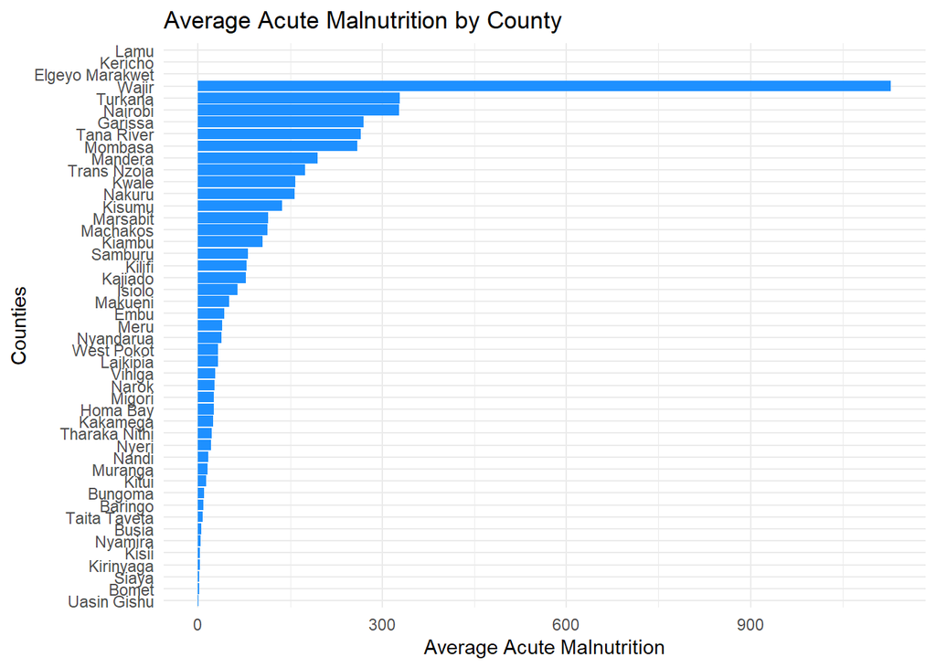

```r
# Load ggplot2
library(ggplot2)

# Calculate the average acute malnutrition value for each county
average_values <- data %>%
  group_by(county) %>%
  summarize(Avg_Acute_Malnutrition = mean(Acute.Malnutrition, na.rm = TRUE))

# Create a horizontal bar plot to visualize the average values
ggplot(average_values, aes(x = Avg_Acute_Malnutrition, y = reorder(county, Avg_Acute_Malnutrition))) +
  geom_bar(stat = "identity", fill = "dodgerblue") +
  labs(x = "Average Acute Malnutrition",
       y = "Counties",
       title = "Average Acute Malnutrition by County") +
  theme_minimal()
```

There might have been Zero-Reporting Bias, meaning there might have been a bias towards reporting zero values instead of missing values. If the missing values are indeed zeros, imputing them with the mean or other values may introduce biases. Therefore, missing values will be imputed with zero.

```r
# Replace missing values with zeros
data <- data %>%
  mutate(
    Acute.Malnutrition = if_else(is.na(Acute.Malnutrition), 0, Acute.Malnutrition),
    stunted.6.23.months = if_else(is.na(stunted.6.23.months), 0, stunted.6.23.months),
    stunted.0..6.months = if_else(is.na(stunted.0..6.months), 0, stunted.0..6.months),
    stunted.24.59.months = if_else(is.na(stunted.24.59.months), 0, stunted.24.59.months)
  )

# Confirm missing values have been replaced
check_and_print_missing_values(data)
```

```
## No missing values found in any column.
```

### Trends Analysis & Age Group Comparison

Let’s explore trends in average deworming and diarrhea cases over the period of the dataset.

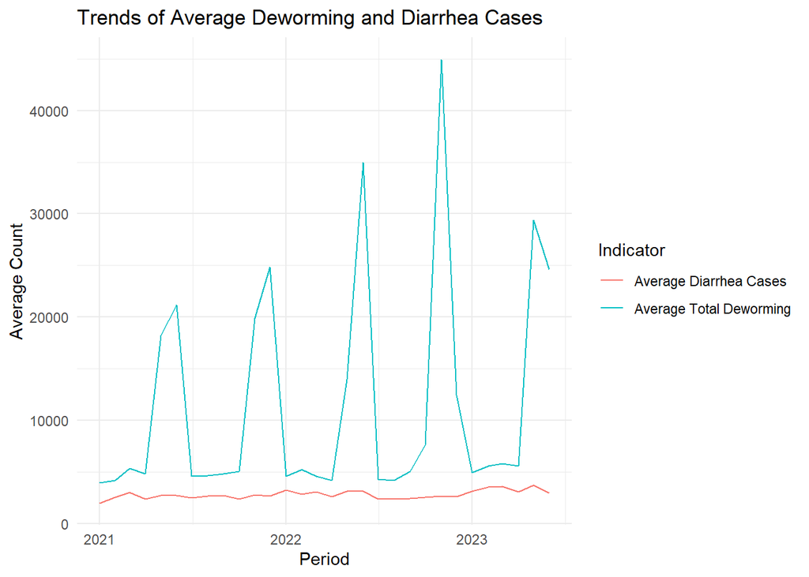

```r
# Convert 'period' to a Date object for proper plotting
data$period <- as.Date(paste("01", data$period), format = "%d %b-%y")

# Calculate the average deworming and average diarrhea cases over time
average_trends <- data %>%
  group_by(period) %>%
  summarize(Avg_Total_Deworming = mean(Total.Dewormed, na.rm = TRUE),
            Avg_Diarrhea_Cases = mean(diarrhoea.cases, na.rm = TRUE))

# Create a line plot to visualize the trends
ggplot(average_trends, aes(x = period)) +
  geom_line(aes(y = Avg_Total_Deworming, color = "Average Total Deworming")) +
  geom_line(aes(y = Avg_Diarrhea_Cases, color = "Average Diarrhea Cases")) +
  labs(x = "Period",
       y = "Average Count",
       title = "Trends of Average Deworming and Diarrhea Cases",
       color = "Indicator") +
  theme_minimal()
```

There seems to be no impact of deworming on cases of diarrhea.

There is stationarity in average diarrhea cases as there is no trend or seasonality. Average diarrhea cases have been relatively unchanged for the period of the data.

Exploring the average stunted cases for the 3 age groups over time:

[figure not shown]

```r
# Calculate the average values for the three specified columns over time
average_trends <- data %>%
  group_by(period) %>%
  summarize(Avg_stunted_6_23_months = mean(`stunted.6.23.months`, na.rm = TRUE),
            Avg_stunted_0_6_months = mean(`stunted.0..6.months`, na.rm = TRUE),
            Avg_stunted_24_59_months = mean(`stunted.24.59.months`, na.rm = TRUE))

# Convert data from wide to long format for better plotting
average_trends_long <- tidyr::pivot_longer(average_trends,
                                           cols = starts_with("Avg_stunted"),
                                           names_to = "Indicator",
                                           values_to = "Average_Count")

# Create a line plot to visualize the temporal trends
ggplot(average_trends_long, aes(x = period, y = Average_Count, color = Indicator)) +
  geom_line() +
  labs(x = "Period",
       y = "Average Count",
       title = "Trends of Average Stunted Cases for Various Ages Groups",
       color = "Indicator") +
  theme_minimal() +
  scale_color_manual(values = c("red", "blue", "green"),
                     labels = c("6-23 months", "0-6 months", "24-59 months"))
```

Exploring underweight cases for the 3 age groups over time:

[figure not shown]

```r
# Calculate average values for the three specified columns over time
average_trends <- data %>%
  group_by(period) %>%
  summarize(Avg_Underweight_0_6_months = mean(`Underweight.0..6.months`, na.rm = TRUE),
            Avg_Underweight_6_23_months = mean(`Underweight.6.23.months`, na.rm = TRUE),
            Avg_Underweight_24_59_months = mean(`Underweight.24.59.Months`, na.rm = TRUE))

# Convert data from wide to long format for better plotting
average_trends_long <- tidyr::pivot_longer(average_trends,
                                           cols = starts_with("Avg_Underweight"),
                                           names_to = "Indicator",
                                           values_to = "Average_Count")

# Create a line plot to visualize the trends
ggplot(average_trends_long, aes(x = period, y = Average_Count, color = Indicator)) +
  geom_line() +
  labs(x = "Period",
       y = "Average Count",
       title = "Trends of Average Underweight Cases for Various Ages Groups",
       color = "Indicator") +
  theme_minimal() +
  scale_color_manual(values = c("purple", "darkorange", "brown"),
                     labels = c("0-6 months", "6-23 months", "24-59 months"))
```

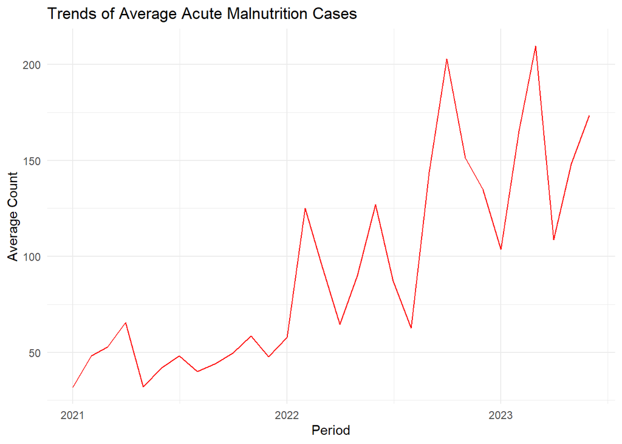

```r
# Calculate the average values for the 'Acute.Malnutrition' column over time
average_trends <- data %>%
  group_by(period) %>%
  summarize(Avg_Acute_Malnutrition = mean(`Acute.Malnutrition`, na.rm = TRUE))

# Create a line plot to visualize the temporal trends for 'Acute.Malnutrition'
ggplot(average_trends, aes(x = period, y = Avg_Acute_Malnutrition)) +
  geom_line(color = "red") +
  labs(x = "Period",
       y = "Average Count",
       title = "Trends of Average Acute Malnutrition Cases",
       color = "Indicator") +
  theme_minimal()
```

Average acute malnutrition cases have been increasing for the period of the dataset. The increasing has been steeper as from 2022.

### County-wise Analysis

We explore regional disparities in child health by looking for significant differences in child health indicators between different counties in Kenya. We also investigate which counties show better or worse outcomes for each indicator.

Plot a bar plot of average stunted cases for the 3 age groups for each county:

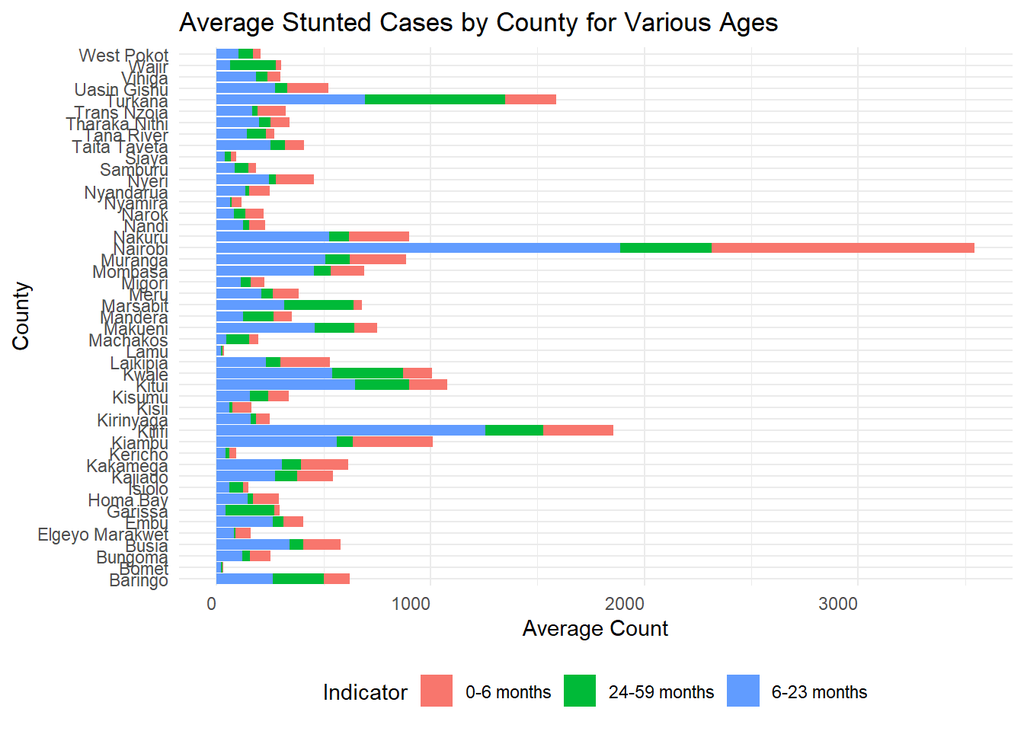

```r
# Calculate the average values for the three specified columns by county
averages_by_county <- data %>%
  group_by(county) %>%
  summarize(Avg_stunted_6_23_months = mean(`stunted.6.23.months`, na.rm = TRUE),
            Avg_stunted_0_6_months = mean(`stunted.0..6.months`, na.rm = TRUE),
            Avg_stunted_24_59_months = mean(`stunted.24.59.months`, na.rm = TRUE))

# Convert data from wide to long format for better plotting
averages_by_county_long <- tidyr::pivot_longer(averages_by_county,
                                              cols = starts_with("Avg_stunted"),
                                              names_to = "Indicator",
                                              values_to = "Average_Count")

# Create a stacked horizontal bar plot
ggplot(averages_by_county_long, aes(y = county, x = Average_Count, fill = Indicator)) +
  geom_bar(stat = "identity") +
  labs(x = "Average Count",
       y = "County",
       title = "Average Stunted Cases by County for Various Ages",
       fill = "Indicator") +
  scale_fill_discrete(labels = c("0-6 months", "24-59 months", "6-23 months")) +
  theme_minimal() +
  theme(axis.text.x = element_text(hjust = 1),
        legend.position = "bottom")
```

For children aged 0-6 months, counties with the highest stunted cases are Nairobi, Kiambu and Kilifi respectively. For children aged 6-23 months, counties with the highest stunted cases are Nairobi, Kilifi and Turkana respectively. For children aged 23-59 months, counties with the highest stunted cases are Turkana, Nairobi and Kwale respectively.

Plot a bar plot of average underweight cases for the 3 age groups for each county:

[figure not shown]

```r
# Calculate the average values for the three specified columns by county
averages_by_county <- data %>%
  group_by(county) %>%
  summarize(Avg_Underweight_0_6_months = mean(`Underweight.0..6.months`, na.rm = TRUE),
            Avg_Underweight_6_23_months = mean(`Underweight.6.23.months`, na.rm = TRUE),
            Avg_Underweight_24_59_months = mean(`Underweight.24.59.Months`, na.rm = TRUE))

# Convert data from wide to long format for better plotting
averages_by_county_long <- tidyr::pivot_longer(averages_by_county,
                                              cols = starts_with("Avg_Underweight"),
                                              names_to = "Indicator",
                                              values_to = "Average_Count")

# Create a stacked horizontal bar plot
ggplot(averages_by_county_long, aes(y = county, x = Average_Count, fill = Indicator)) +
  geom_bar(stat = "identity") +
  labs(x = "Average Count",
       y = "County",
       title = "Average Underweight Cases by County for Various Ages",
       fill = "Indicator") +
  scale_fill_discrete(labels = c("0-6 months", "6-23 months", "24-59 months")) +
  theme_minimal() +
  theme(axis.text.x = element_text(hjust = 1),
        legend.position = "bottom")
```

Plot of total dewormed from January 2021 to June 2023 for each county:

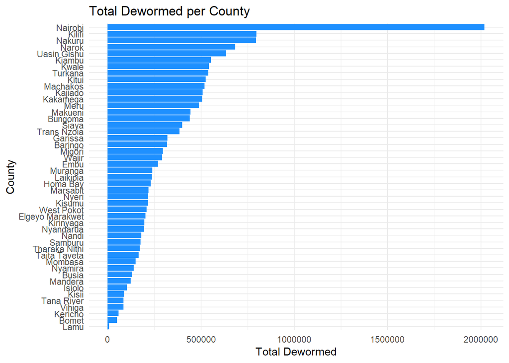

```r
# Calculate the sum of Total Deworming for each county for the entire period
sum_by_county <- data %>%
  group_by(county) %>%
  summarize(Sum_Total_Dewormed = sum(Total.Dewormed, na.rm = TRUE)) %>%
  arrange(desc(Sum_Total_Dewormed))  # Sort in descending order

# Convert the 'county' column to a factor with levels sorted in descending order of the sum
sum_by_county$county <- factor(sum_by_county$county,
                               levels = rev(sum_by_county$county))

# Create a horizontal bar plot to visualize the sum of Total Dewormed per county
ggplot(sum_by_county, aes(x = Sum_Total_Dewormed, y = county)) +
  geom_bar(stat = "identity", fill = "dodgerblue") +
  labs(x = "Total Dewormed",
       y = "County",
       title = "Total Dewormed per County",
       fill = "") +
  theme_minimal()
```

Nairobi, Kilifi, Nakuru and Narok counties have the highest total dewormed number of children while Lamu, Bomet, Kericho and Vihiga counties have the lowest dewormed children.

Plot the total diarrhea cases from January 2021 to June 2023 for each county:

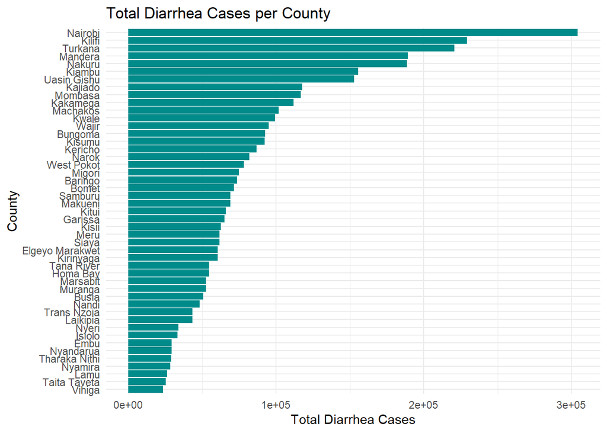

```r
# Calculate the sum of diarrhea cases for each county for the entire period
sum_diarrhea_by_county <- data %>%
  group_by(county) %>%
  summarize(Sum_Diarrhea_Cases = sum(diarrhoea.cases, na.rm = TRUE)) %>%
  arrange(desc(Sum_Diarrhea_Cases))  # Sort in descending order

# Convert the 'county' column to a factor with levels sorted in descending order of the sum
sum_diarrhea_by_county$county <- factor(sum_diarrhea_by_county$county,
                                        levels = rev(sum_diarrhea_by_county$county))

# Create a horizontal bar plot to visualize the sum of diarrhea cases per county
ggplot(sum_diarrhea_by_county, aes(x = Sum_Diarrhea_Cases, y = county)) +
  geom_bar(stat = "identity", fill = "cyan4") +
  labs(x = "Total Diarrhea Cases",
       y = "County",
       title = "Total Diarrhea Cases per County",
       fill = "") +
  theme_minimal()
```

Counties with the most diarrhea cases are Nairobi, Kilifi, Turkana and Mandera counties while counties with the least diarrhea cases are Vihiga, Taita Taveta, Lamu and Nyamira.

### Geospatial Analysis

Choropleth maps will be plotted to quickly identify spatial patterns and trends in the data. By visualizing health indicators on a map, we will easily see which areas have higher or lower values, clusters, or gradients of the variables. The maps will help us understand regional disparities in child health indicators.

Loading the shapefile and inspecting it:

```r
# Load sf library
library(sf)
# Read the shapefile
shapefile <- st_read("shapefiles")
# Preview the shapefile
head(shapefile)
```

```
## Simple feature collection with 6 features and 8 fields
## Geometry type: MULTIPOLYGON
## Dimension:     XY
## Bounding box:  xmin: 37.58447 ymin: -4.798828 xmax: 41.56909 ymax: -0.001525879
## Geodetic CRS:  WGS 84
##   fid OBJECTID ID         Name Code Shape_Leng Shape_Area        Area
## 1   1        1  1      Mombasa  MBA  0.8855862 0.02332511   286423166
## 2   2        2  2        Kwale  KLE  4.2841818 0.75826601  9309279431
## 3   3        3  3       Kilifi  KLF  5.3330801 1.02533838 12601873866
## 4   4        4  4   Tana River  TAN 10.2804494 3.18421264 39177464255
## 5   5        5  5         Lamu  LAU  3.7446892 0.74374311  9148878656
## 6   6        6  6 Taita Taveta  TVT  5.5844513 1.39385877 17126899316
##                         geometry
## 1 MULTIPOLYGON (((39.6825 -4....
## 2 MULTIPOLYGON (((39.32031 -3...
## 3 MULTIPOLYGON (((39.71051 -3...
## 4 MULTIPOLYGON (((39.02753 -0...
## 5 MULTIPOLYGON (((41.07727 -2...
## 6 MULTIPOLYGON (((38.17328 -2...
```

Merging the data with the shapefile and plotting a choropleth map of the total number of children with acute malnutrition:

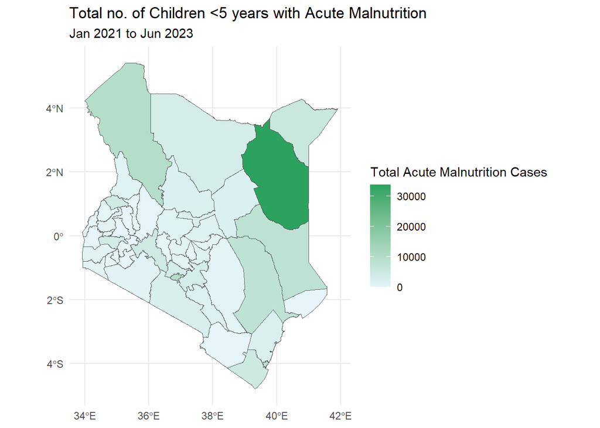

```r
# Step 1: Aggregate the data to get total Acute Malnutrition cases for each county
aggregated_data <- data %>%
  group_by(county) %>%
  summarize(Total_Acute_Malnutrition = sum(Acute.Malnutrition, na.rm = TRUE))

# Step 2: Merge aggregated data with the shapefile
merged_data <- merge(shapefile, aggregated_data, by.x = "Name", by.y = "county")

# Set the CRS for the merged_data to match the CRS of the shapefile
st_crs(merged_data) <- st_crs(shapefile)

# Step 3: Create the choropleth map for total Acute Malnutrition cases
ggplot() +
  geom_sf(data = merged_data, aes(fill = Total_Acute_Malnutrition)) +
  scale_fill_gradient(low = "#e5f5f9", high = "#2ca25f") +
  labs(title = "Total no. of Children <5 years with Acute Malnutrition",
       subtitle = "Jan 2021 to Jun 2023",
       fill = "Total Acute Malnutrition Cases") +
  theme_minimal()
```

Wajir County has the highest total acute malnutrition cases for the timeframe of the data.

Plotting a choropleth map of the total number of children with diarrhea:

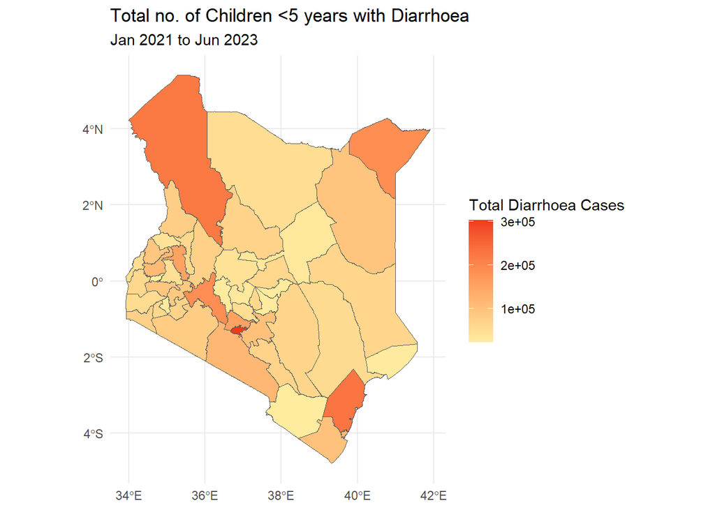

```r
# Aggregate the data to get total diarrhoea cases for each county
aggregated_data <- data %>%
  group_by(county) %>%
  summarize(Total_diarrhoea_cases = sum(diarrhoea.cases, na.rm = TRUE))

# Merge aggregated data with the shapefile
merged_data <- merge(shapefile, aggregated_data, by.x = "Name", by.y = "county")

# Set the CRS for the merged_data to match the CRS of the shapefile
st_crs(merged_data) <- st_crs(shapefile)

# Create the choropleth map for total diarrhoea cases
ggplot() +
  geom_sf(data = merged_data, aes(fill = Total_diarrhoea_cases)) +
  scale_fill_gradient(low = "#ffeda0", high = "#f03b20") +
  labs(title = "Total no. of Children <5 years with Diarrhoea",
       subtitle = "Jan 2021 to Jun 2023",
       fill = "Total Diarrhoea Cases") +
  theme_minimal()
```

Nairobi, Turkana and Kilifi counties have the most number cases of diarrhea reported.

Plotting a choropleth map of the total number of children dewormed:

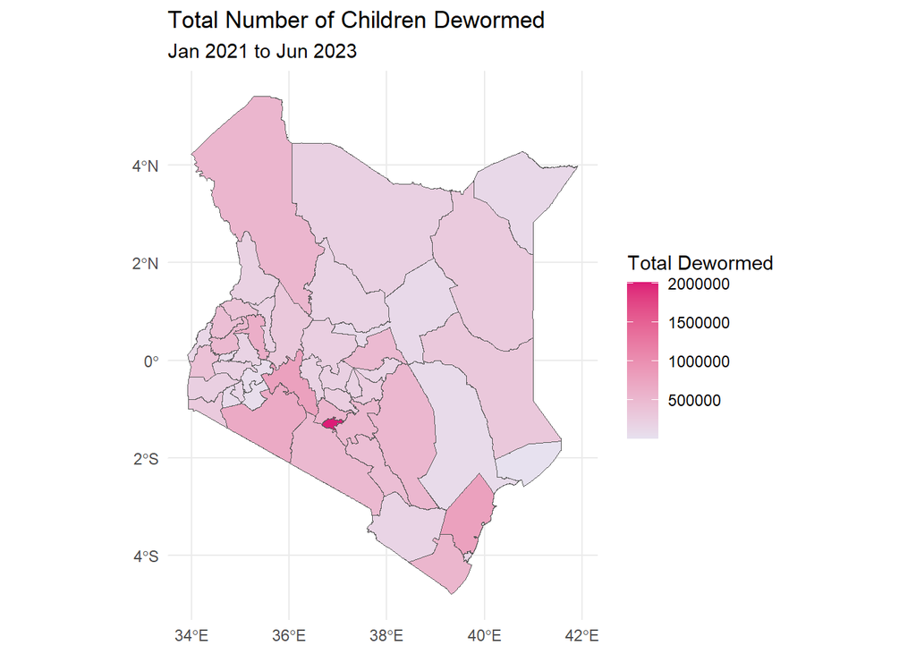

```r
# Aggregate the data to get total dewormed cases for each county
aggregated_data <- data %>%
  group_by(county) %>%
  summarize(Total_dewormed = sum(Total.Dewormed, na.rm = TRUE))

# Merge aggregated data with the shapefile
merged_data <- merge(shapefile, aggregated_data, by.x = "Name", by.y = "county")

# Set the CRS for the merged_data to match the CRS of the shapefile
st_crs(merged_data) <- st_crs(shapefile)

# Create the choropleth map
ggplot() +
  geom_sf(data = merged_data, aes(fill = Total_dewormed)) +
  scale_fill_gradient(low = "#e7e1ef", high = "#dd1c77") +
  labs(title = "Total Number of Children Dewormed",
       subtitle = "Jan 2021 to Jun 2023",
       fill = "Total Dewormed") +
  theme_minimal()
```

Nairobi County has the most number of dewormings done.

Plotting a choropleth map of the average number of underweight children aged 24-59 months:

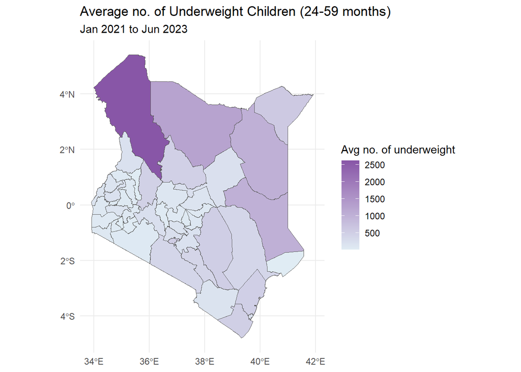

```r
# Aggregate the data to get avg underweight (24-59) months for each county
aggregated_data <- data %>%
  group_by(county) %>%
  summarize(Avg_Underweight_24_59 = mean(Underweight.24.59.Months, na.rm = TRUE))

# Merge aggregated data with the shapefile
merged_data <- merge(shapefile, aggregated_data, by.x = "Name", by.y = "county")

# Set the CRS for the merged_data to match the CRS of the shapefile
st_crs(merged_data) <- st_crs(shapefile)

# Create the choropleth map
ggplot() +
  geom_sf(data = merged_data, aes(fill = Avg_Underweight_24_59)) +
  scale_fill_gradient(low = "#e0ecf4", high = "#8856a7") +
  labs(title = "Average no. of Underweight Children (24-59 months)",
       subtitle = "Jan 2021 to Jun 2023",
       fill = "Avg no. of underweight") +
  theme_minimal()
```

Turkana, Marsabit, Wajir and Garissa counties have the highest cases of underweight children aged 24-59 months.

Plotting a choropleth map of the average number of stunted children aged 24-59 months:

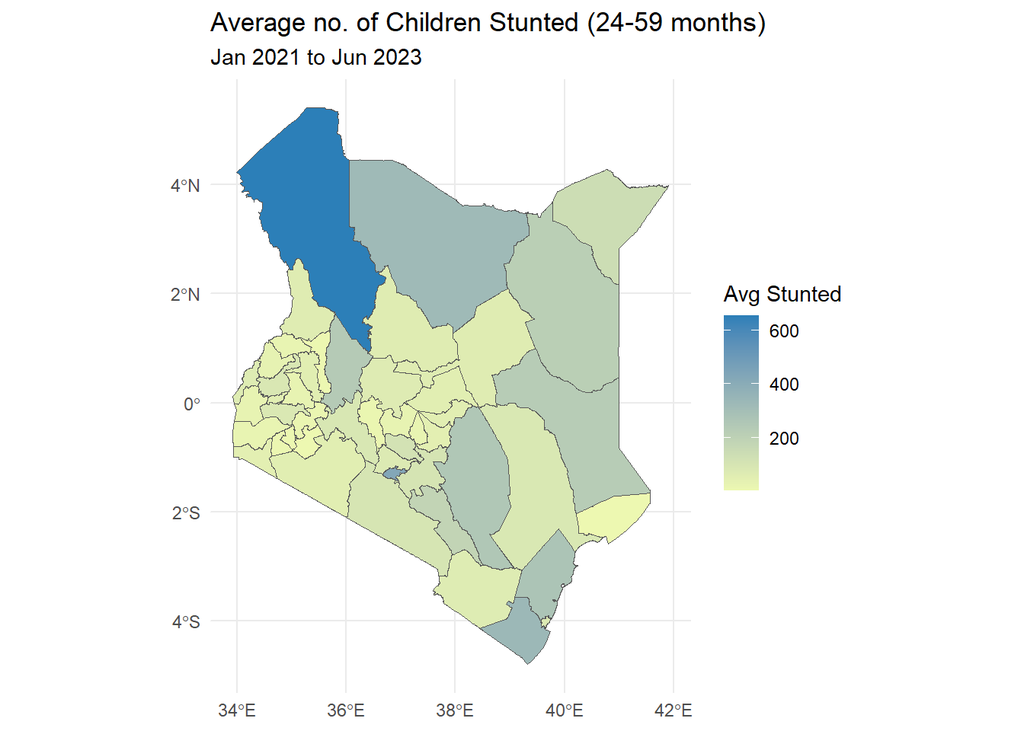

```r
# Aggregate the data to get avg stunted (24-59) months for each county
aggregated_data <- data %>%
  group_by(county) %>%
  summarize(Avg_stunted_24_59 = mean(stunted.24.59.months, na.rm = TRUE))

# Merge aggregated data with the shapefile
merged_data <- merge(shapefile, aggregated_data, by.x = "Name", by.y = "county")

# Set the CRS for the merged_data to match the CRS of the shapefile
st_crs(merged_data) <- st_crs(shapefile)

# Create the choropleth map
ggplot() +
  geom_sf(data = merged_data, aes(fill = Avg_stunted_24_59)) +
  scale_fill_gradient(low = "#edf8b1", high = "#2c7fb8") +
  labs(title = "Average no. of Children Stunted (24-59 months)",
       subtitle = "Jan 2021 to Jun 2023",
       fill = "Avg Stunted") +
  theme_minimal()
```

Nairobi County and counties in the northern and north eastern regions of the country have high numbers of stunted children aged 24-59 months.

## Conclusion

Below are the conclusions drawn from this analysis:

Overall, the observations highlight the importance of continuous efforts to combat child health challenges, such as stunting and underweight cases, through targeted interventions, especially in specific age groups and high-burden counties. The lack of a noticeable impact of deworming on diarrhea cases might suggest the need to explore additional interventions to address diarrhea-related issues.

There was a challenge faced in this analysis caused by the limited timeframe of the data. Data spanning a longer period would provide more insights by revealing more trends and be suitable for predictive modelling.

## Recommendations

Based on the conclusions drawn from this analysis, below are the recommendations for the non-profit organization:

- **Enhance Deworming Strategies:** Given the observed seasonality in deworming activities and the increasing trend in deworming efforts, the organization should continue its efforts to deworm children regularly. However, to potentially address the lack of impact on diarrhea cases, the organization could consider evaluating the efficacy of the current deworming protocols and explore complementary interventions to reduce diarrheal diseases.
- **Targeted Nutrition Interventions:** The increasing trend in stunted and underweight cases calls for targeted nutrition interventions for specific age groups, particularly for children aged 6-23 months and 24-59 months. The organization should focus on providing nutritional support, education, and access to nutrient-rich foods to combat malnutrition effectively.
- **Acute Malnutrition Management:** Given the steeper increase in acute malnutrition cases from 2022, the organization should strengthen its acute malnutrition management programs. Early detection and timely treatment can help prevent severe cases and associated complications.
- **Regional Focus:** The organization should take into account the regional disparities observed in child health indicators. By tailoring interventions based on the specific health needs of each county, the organization can ensure that resources are directed where they are most needed.

By implementing these recommendations, the non-profit organization can make significant strides in improving child health in Kenya, addressing malnutrition, reducing disease burden, and ensuring healthier outcomes for children across the country.